# Portuguese elections: Which color for which party?

Gil J. B. Henriques

25/06/2020

In 2018, Lisa Charlotte Rose wrote a [Chartable article](https://blog.datawrapper.de/partycolors/) about the colors used in political reporting to represent political parties in Germany, the UK, and the US. Arnold Platon followed up with a [post](https://arnoldplaton.wordpress.com/2018/12/) taking a similar look at colors used to represent European Parliament political groups.

Inspired by their articles, I thought it would be fun to do the same exercise for Portuguese political parties. In 2019, there were both legislative and European elections, which means a large number of newspapers, magazines, and TV channels made charts to communicate polls and results. A result of these elections was an explosion in the number of parties represented in parliament, from five/six to nine, which generated a sudden confusion in what colors to use to represent each party.

I combed through a number of 2019 articles and compiled a list of the colors that different publications used to represent parties in 2019. First, let’s take a look at each party separately, representing the colors used by different publications in a color wheel:

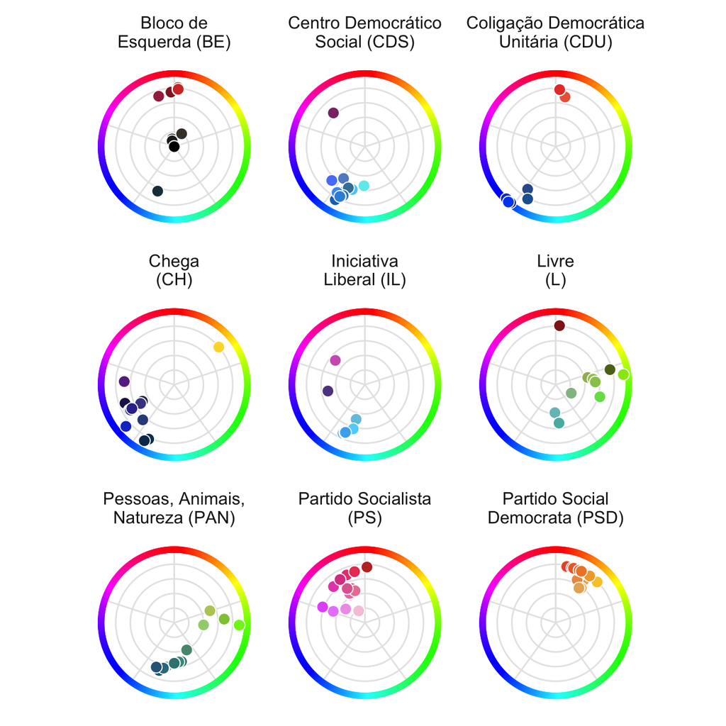

Here’s how to read this plot: for each party, the points map the color used by different publications. The wheel around the circumference indicates the color hue. The closer a color is to the center, the lower is the saturation. Where the color is located on the plot gives no information about how light or dark it is.

To delve deeper, let’s take a look at the colors chosen by each newsroom:

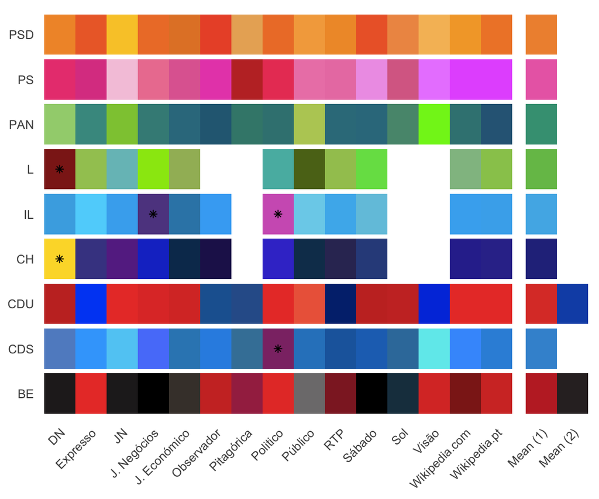

For some of the smallest parties (particularly L, CH, CDS and IL) there is a lack of consensus on what color to use. For example, most publications use light green to represent the green-left party Livre (L), but DN chose dark red (presumably because of this party’s left-wing stance). The same newspaper used yellow to represent far-right party Chega (CH), whereas most other publications went with dark blue. Particularly original color choices like these are marked with an asterisk (*), and were not taken into consideration when calculating the consensus colors.

Let’s take a look at where these consensus colors fit in the color wheel:

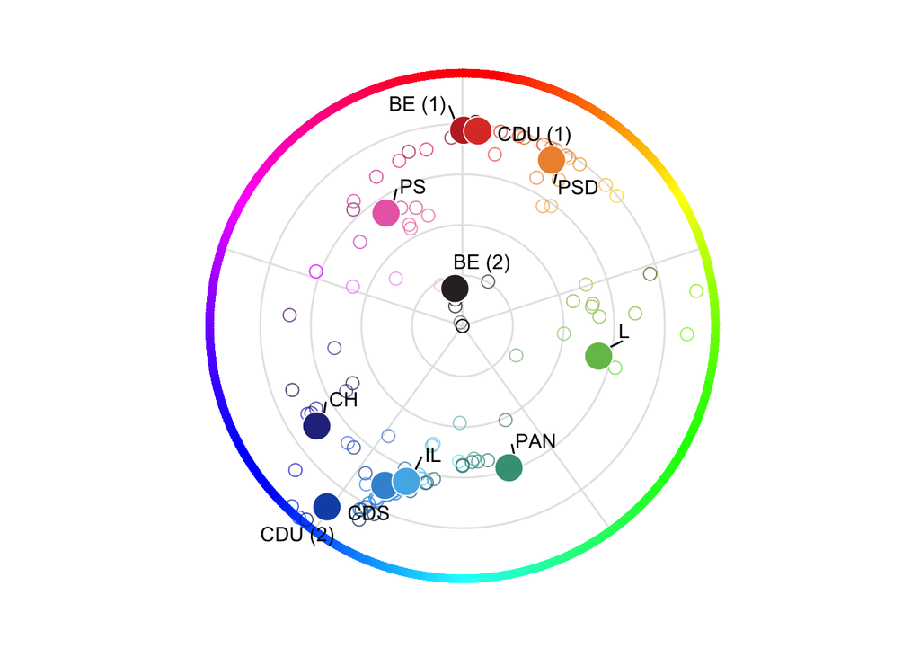

The biggest challenge in representing political parties is the large number of hues of blue. At least three different shades—lighter for liberal IL, medium for center-right CDS, and darker for far-right CH—are needed. Some publications attempt to solve this problem by assigning colors from less crowded corners of the color wheel to one of the three parties, like DN (which goes with yellow for CH) or Politico (which uses a purplish shade of pink for IL), but these are unconventional solutions.

It doesn’t help that one of the two conventional choices for left-wing CDU is dark-blue as well. It is likely that, with the explosion of new right-wing parties that are associated with the color blue, more publications will opt to use red to represent CDU. Those that do so are likely to use darker shades of red or black to represent the other left-wing party, BE. In fact, *every single one* of the sampled newspapers that chooses to represent BE in black uses red for CDU.